به نام خدا

# برنامه‌سازی پیشرفته

دانشگاه شهید بهشتی · دانشکده مهندسی کامپیوتر

دکتر مجتبی وحیدی اصل

### آشنایی با شیءگرایی - بخش دوم

نازنین فروتن

## فهرست مطالب

1. انگیزه
2. اشیا و کلاس‌های تغییرناپذیر (Immutable)
3. حوزه متغیرها
4. سطوح دسترسی در جاوا
- **private**
- **default**
- **protected**
- **public**
5. کلمه کلیدی this
6. انتزاع و کپسوله‌سازی
7. طراحی کلاس Loan (وام)
8. طراحی کلاس BMI (شاخص توده بدنی)
9. مثال: کلاس Course (درس)
10. مثال: کلاس StackOfIntegers (پشته اعداد صحیح)

## انگیزه

در جلسه قبل با برخی مزایای برنامه نویسی شیءگرا آشنا شدیم.

در این جلسه برخی دیگر از این مزایا را با ارائه مثال بررسی خواهیم نمود.

## اشیا و کلاس‌های تغییرناپذیر (immuatable)

- اگر محتوای یک شیء پس از ایجاد آن نتواند تغییر کند، به آن شیء تغییرناپذیر گفته می‌شود و کلاس مربوطه کلاس تغییرناپذیر نامیده می‌شود.
- اگر شما متد set در کلاس Circle را در قطعه کد بعدی حذف کنید، کلاس تغییرناپذیر خواهد شد؛ چون radious سطح دسترسی private دارد و بدون متد set قابل دستکاری نمی‌باشد.

کلاسی که همه فیلدهای آن private هستند، بدون وجود تغییر‌دهنده‌ها (mutators) لزوماً تغییرناپذیر نمی‌باشد. برای مثال کلاس Student که همه فیلدهای آن private است و متد تغییر‌دهنده ندارد، همچنان تغییرپذیر می‌باشد.

```java
/* مثالی از کلاس تغییر پذیر */

public class Circle3 {
    /** The radius of the circle */
    private double radius = 1;

    /** Construct a circle with a specified radius */
    public Circle3(double newRadius) {
        radius = newRadius;
        numberOfObjects++;
    }

    /** Return radius */
    public double getRadius() {
        return radius;
    }

    /** Set a new radius */
    public void setRadius(double newRadius) {
        radius = (newRadius >= 0) ? newRadius : 0;
    }

    /** Return the area of this circle */
    public double getArea() {
        return radius * radius * Math.PI;
    }
}
```

```java
/* مثالی از کلاس تغییر ناپذیر */


public class Circle3 {
    /** The radius of the circle */
    private double radius = 1;

    /** Construct a circle with a specified radius */
    public Circle3(double newRadius) {
        radius = newRadius;
        numberOfObjects++;
    }

    /** Return radius */
    public double getRadius() {
        return radius;
    }

    /** Set a new radius */
    private void setRadius(double newRadius) {
        radius = (newRadius >= 0) ? newRadius : 0;
    }

    /** Return the area of this circle */
    public double getArea() {
        return radius * radius * Math.PI;
    }
}
```

#### **مثال**

```java
public class BirthDate {
    private int year;
    private int month;
    private int day;

    public BirthDate(int newYear, int newMonth, int newDay) {
        year = newYear;
        month = newMonth;
        day = newDay;
    }

    public void setYear(int newYear) {
        year = newYear;
    }
}
```

```java
public class Student {
    private int id;
    private BirthDate birthDate;

    public Student(int ssn, int year, int month, int day) {
        id = ssn;
        birthDate = new BirthDate(year, month, day);
    }

    public int getId() {
        return id;
    }

    public BirthDate getBirthDate() {
        return birthDate;
    }
}
```

```java
public class Test {
    public static void main(String[] args) {
        Student student = new Student(111223333, 1970, 5, 3);
        BirthDate date = student.getBirthDate();
        date.setYear(2010); // Now the student birth year is changed!
    }
}

Test.main(new String[] {});
```

#### **چه کلاسی تغییرناپذیر است؟**

برای اینکه کلاس تغییرناپذیر باشد، همه فیلدهای داده‌ای آن باید private تعریف شوند و هیچ متد تغییر‌دهنده یا متد دسترسی وجود نداشته باشد که ارجاعی به یک فیلد داده‌ای قابل تغییر را برگردانند.

### حوزه متغیرها

- حوزه متغیرهای نمونه و استاتیک کل محدوده کلاس است. این متغیرها می‌توانند در هر جایی داخل کلاس تعریف شوند.
- حوزه یک متغیر محلی از نقطه اعلان آن آغاز و تا انتهای بلاکی که حاوی آن متغیر است ادامه می‌یابد. یک متغیر محلی باید پیش از استفاده مقداردهی شده باشد.

### سطوح دسترسی در جاوا - بررسی دقیق‌تر

- تغییر‌دهنده‌های دسترسی (access modifiers) در جاوا دسترس‌پذیری (حوزه) یک فیلد داده‌ای، متد، سازنده یا کلاس را مشخص می‌کند.
- در جاوا چهار سطح دسترسی اصلی برای متغیرها، متدها و کلاس‌ها وجود دارد. این سطوح دسترسی میزان قابل‌مشاهده بودن (visibility) و امکان استفاده از آن‌ها در سایر کلاس‌ها یا پکیج‌ها را مشخص می‌کنند:
1. **private**: فقط در داخل همان کلاس قابل دسترسی است.
2. **default (package-private)**: در صورت عدم ذکر سطح دسترسی، فقط در همان پکیج قابل دسترسی خواهد بود.
3. **protected**: در همان پکیج و همچنین در کلاس‌های فرزند (subclass) حتی در پکیج‌های دیگر قابل دسترسی است.
4. **public**: در همه جا بدون محدودیت قابل دسترسی است.

#### **تغییردهنده دسترسی private**

اگر سازنده یک کلاس را private تعریف کنیم، نمی‌توانیم نمونه‌ای از کلاس را در خارج از آن کلاس ایجاد کنیم.

```java
class A {
    private A() {} // private constructor

    void msg() {
        System.out.println("Hello java");
    }
}

public class Simple {
    public static void main(String args[]) {
        A obj = new A(); // Compile Time Error
    }
}

A.main(new String[] {});
```

#### **تغییردهنده دسترسی default**

```java
class A {
    void msg() {
        System.out.println("Hello");
    }
}

class B {
    public static void main(String[] args) {
        A obj = new A();
        obj.msg();
    }
}

B.main(new String[]{});
```

#### **تغییردهنده دسترسی protected**

```java
public class A {
    protected void msg() {
        System.out.println("Hello");
    }
}

public class B extends A {
    public static void main(String[] args) {
        B obj = new B();
        obj.msg();
    }
}

B.main(new String[]{});
```

#### **تغییردهنده دسترسی public**

- در همه جا قابل دسترسی است!
- وسیع‌ترین حوزه دسترسی میان سایر تغییر‌دهنده‌ها را دارد.

```java
// save by A.java
public class A {
    public void msg() {
        System.out.println("Hello");
    }
}

// save by B.java
class B {
    public static void main(String args[]) {
        A obj = new A();
        obj.msg();
    }
}

B.main(new String[]{});
```

#### **جدول سطوح دسترسی در جاوا**

[figure not shown]

## کلمه کلیدی this

- کلمه کلیدی **this** نام ارجاعی است که به خود یک شیء اشاره می‌کند.
- کاربرد مهم آن ارجاع به متغیر نمونه کلاس فعلی (جاری) است.
- ()This برای فراخوانی سازنده کلاس فعلی استفاده می‌شود.
- برای فراخوانی متد کلاس فعلی به طور ضمنی استفاده می‌شود.
- می‌تواند به عنوان آرگومان در فراخوانی یک متد استفاده شود.
- می‌تواند به عنوان آرگومان در فراخوانی سازنده ارسال شود.
- به یک سازنده امکان می‌دهد، سازنده دیگری از همان کلاس را فراخوانی نماید.
- برای برگرداندن نمونه کلاس فعلی استفاده می‌شود.

**نکته:** کلمه کلیدی this به نمونه فعلی کلاس اشاره می‌کند.

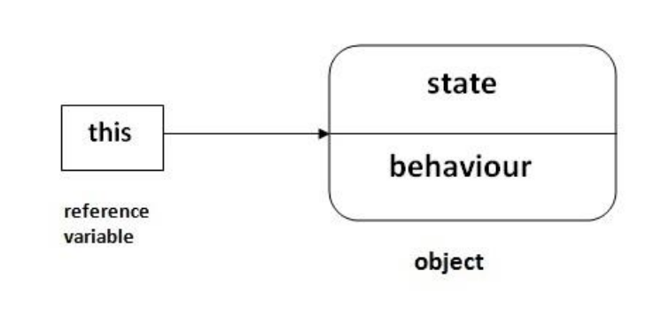

هرگاه میان متغیر نمونه و پارامتر ارسالی، ابهام وجود داشته باشه، this برای رفع ابهام به کار می‌رود.

برای مثال در کد زیر از this استفاده نمی‌کنیم و در نتیجه دچار ابهام شدیم:

```java
class Student10 {
    int id;
    String name;

    Student10(int id, String name) {
        id = id;
        name = name;
    }

    void display() {
        System.out.println(id + " " + name);
    }

    public static void main(String args[]) {
        Student10 s1 = new Student10(111, "Karan");
        Student10 s2 = new Student10(321, "Aryan");
        s1.display();
        s2.display();
    }
}
```

**ارجاع به متغیر نمونه کلاس فعلی به عنوان فیلد پنهان**

در مثال قبلی، پارامتر متد (آرگومان‌های فرمال) و متغیرهای نمونه یکی هستند و به همین دلیل برای تمایز آنها از کلمه this استفاده می‌شود.

```java
// example of this keyword
class Student11 {
    int id;
    String name;

    Student11(int id, String name) {
        this.id = id;
        this.name = name;
    }

    void display() {
        System.out.println(id + " " + name);
    }

    public static void main(String args[]) {
        Student11 s1 = new Student11(111, "Karan");
        Student11 s2 = new Student11(222, "Aryan");
        s1.display();
        s2.display();
    }
}

Student11.main(new String[]{});
```

**نکته:** کلمه کلیدی this به فیلد‌های داده‌ای اشیای کلاس جاری اشاره می‌کند.

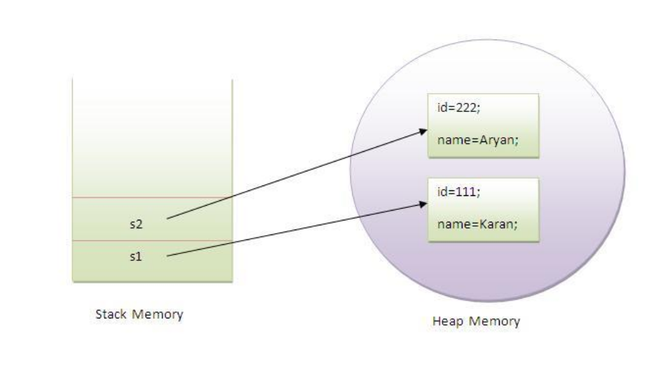

**نکته:** اگر نام متغیرهای نمونه و پارامترهای متد کلاس متفاوت باشند، **در این صورت به this نیازی نداریم.**

```java
class Student12 {
    int id;
    String name;

    Student12(int i, String n) {
        id = i;
        name = n;
    }

    void display() {
        System.out.println(id + " " + name);
    }

    public static void main(String args[]) {
        Student12 e1 = new Student12(111, "Karan");
        Student12 e2 = new Student12(222, "Aryan");
        e1.display();
        e2.display();
    }
}

Student12.main(new String[]{});
```

**نکته:** فراخوانی سازنده this() می‌تواند برای فراخوانی سازنده کلاس فعلی (زنجیره سازنده‌ها) استفاده شود.

```java
// Program of this() constructor call (constructor chaining)
class Student13 {
    int id;
    String name;

    Student13() {
        System.out.println("default constructor is invoked");
    }

    Student13(int id, String name) {
        this(); // it is used to invoke current class constructor.
        this.id = id;
        this.name = name;
    }

    void display() {
        System.out.println(id + " " + name);
    }

    public static void main(String args[]) {
        Student13 e1 = new Student13(111, "Karan");
        Student13 e2 = new Student13(222, "Aryan");
        e1.display();
        e2.display();
    }
}

Student13.main(new String[]{});
```

**چه موقع از فراخوانی سازنده this() استفاده کنیم؟**

- فراخوانی سازنده this() در مواقع استفاده مجدد از یک سازنده در سازنده دیگر استفاده می‌شود.
- این کلمه زنجیره‌ای را میان سازنده‌ها برقرار می‌کند.

```java
class Student14 {
    int id;
    String name;
    String city;

    Student14(int id, String name) {
        this.id = id;
        this.name = name;
    }

    Student14(int id, String name, String city) {
        this(id, name); // now no need to initialize id and name
        this.city = city;
    }

    void display() {
        System.out.println(id + " " + name + " " + city);
    }

    public static void main(String args[]) {
        Student14 e1 = new Student14(111, "Karan");
        Student14 e2 = new Student14(222, "Aryan", "delhi");
        e1.display();
        e2.display();
    }
}

Student14.main(new String[]{});
```

**یک قاعده:** فراخوانی this() باید اولین جمله در سازنده باشد.

```java
class Student15 {
    int id;
    String name;

    Student15() {
        System.out.println("default constructor is invoked");
    }

    Student15(int id, String name) {
        id = id;
        name = name;
        this(); // must be the first statement
    }

    void display() {
        System.out.println(id + " " + name);
    }

    public static void main(String args[]) {
        Student15 e1 = new Student15(111, "Karan");
        Student15 e2 = new Student15(222, "Aryan");
        e1.display();
        e2.display();
    }
}

Student15.main(new String[]{});
```

**کلمه this می‌تواند برای فراخوانی متد کلاس فعلی (به طور ضمنی) استفاده شود.**

- شما می‌توانید متدی از کلاس جاری (فعلی) با this فراخوانی کنید.
- اگر شما از این کلمه استفاده نکنید، کامپایلر به طور خودکار این کلمه را در هنگام فراخوانی متد اضافه می‌کند. برای مثال:

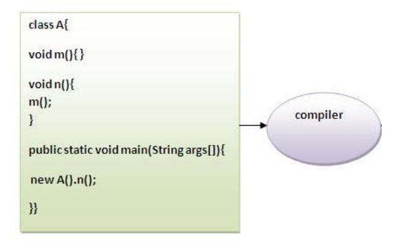

```java
// یک مثال دیگر

class S {
    void m() {
        System.out.println("method is invoked");
    }

    void n() {
        this.m(); // no need because compiler does it for you.
    }

    void p() {
        n(); // compiler will add this to invoke n() method as this.n()
    }

    public static void main(String args[]) {
        S s1 = new S();
        s1.p();
    }
}

S.main(new String[]{});
```

**آیا this دقیقا همان ریموت کنترل شیئ است؟**

- برای اثبات اینکه this به متغیر نمونه کلاس قعلی اشاره می‌کند، برنامه زیر را ملاحظه کنید:

```java
class A5 {
    void m() {
        System.out.println(this); // prints same reference ID
    }

    public static void main(String args[]) {
        A5 obj = new A5();
        System.out.println(obj); // prints the reference ID

        obj.m();
    }
}

A5.main(new String[]{});
```

## انتزاع و بسته‌بندی کلاس

- انتزاع کلاس به معنای تفکیک پیاده‌سازی کلاس از استفاده آن کلاس است.
- ایجادکننده کلاس توصیف (توضیحاتی) از کلاس را ارائه می‌کند و به کاربر می‌گوید چگونه از کلاس استفاده کند.
- کاربر کلاس نیاز نیست بداند کلاس چگونه نوشته شده (پیاده‌سازی شده است). جزئیات پیاده‌سازی بسته‌بندی (کپسوله‌بندی) شده از دید کاربر پنهان است.

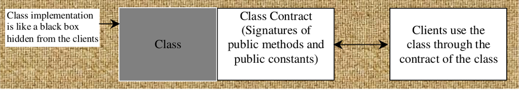

## طراحی کلاس وام

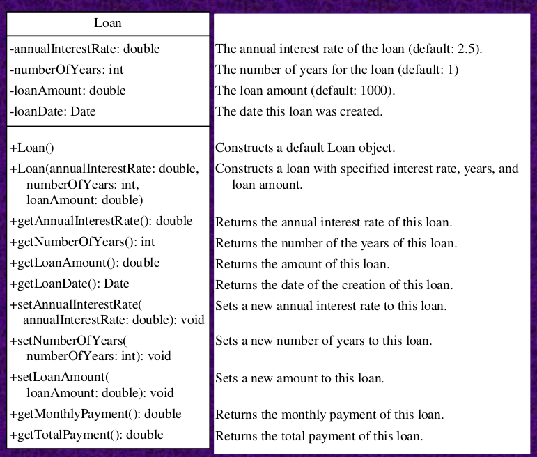

```java
public class Loan {
    private double annualInterestRate;
    private int numberOfYears;
    private double loanAmount;
    private java.util.Date loanDate;

    /** Default constructor */
    public Loan() {
        this(2.5, 1, 1000);
    }

    /** Construct a loan with specified annual interest rate,
        number of years and loan amount */
    public Loan(double annualInterestRate, int numberOfYears, double loanAmount) {
        this.annualInterestRate = annualInterestRate;
        this.numberOfYears = numberOfYears;
        this.loanAmount = loanAmount;
        loanDate = new java.util.Date();
    }

    /** Return annualInterestRate */
    public double getAnnualInterestRate() {
        return annualInterestRate;
    }

    /** Set a new annualInterestRate */
    public void setAnnualInterestRate(double annualInterestRate) {
        this.annualInterestRate = annualInterestRate;
    }

    /** Return numberOfYears */
    public int getNumberOfYears() {
        return numberOfYears;
    }

    /** Set a new numberOfYears */
    public void setNumberOfYears(int numberOfYears) {
        this.numberOfYears = numberOfYears;
    }

    /** Return loanAmount */
    public double getLoanAmount() {
        return loanAmount;
    }

    /** Set a new loanAmount */
    public void setLoanAmount(double loanAmount) {
        this.loanAmount = loanAmount;
    }

    /** Find monthly payment */
    public double getMonthlyPayment() {
        double monthlyInterestRate = annualInterestRate / 1200;
        double monthlyPayment = loanAmount * monthlyInterestRate /
                (1 - (Math.pow(1 / (1 + monthlyInterestRate), numberOfYears * 12)));
        return monthlyPayment;
    }

    /** Find total payment */
    public double getTotalPayment() {
        double totalPayment = getMonthlyPayment() * numberOfYears * 12;
        return totalPayment;
    }

    /** Return loan date */
    public java.util.Date getLoanDate() {
        return loanDate;
    }
}
```

```java
import java.util.Scanner;

public class TestLoanClass {
    /** Main method */
    public static void main(String[] args) {

        double annualInterestRate = 8.25;
        int numberOfYears = 5;
        double loanAmount = 120000.95;

        /*
        // Create a Scanner
        Scanner input = new Scanner(System.in);

        // Enter yearly interest rate
        System.out.print(
            "Enter yearly interest rate, for example, 8.25: ");
        double annualInterestRate = input.nextDouble();

        // Enter number of years
        System.out.print("Enter number of years as an integer: ");
        int numberOfYears = input.nextInt();

        // Enter loan amount
        System.out.print("Enter loan amount, for example, 120000.95: ");
        double loanAmount = input.nextDouble();
        */


        // Create Loan object
        Loan loan = new Loan(annualInterestRate, numberOfYears, loanAmount);

        // Display loan date, monthly payment, and total payment
        System.out.printf("The loan was created on %s%n" +
            "The monthly payment is %.2f%nThe total payment is %.2f%n",
            loan.getLoanDate().toString(), loan.getMonthlyPayment(),
            loan.getTotalPayment());
    }
}


TestLoanClass.main(new String[]{});
```

## طراحی کلاس ‌BMI (Body Mass Index)

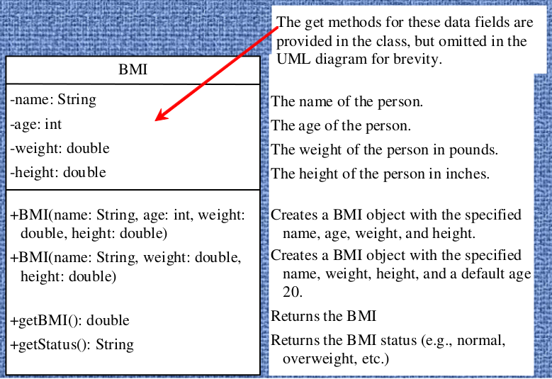

```java
public class BMI {
    private String name;
    private int age;
    private double weight; // in pounds
    private double height; // in inches
    public static final double KILOGRAMS_PER_POUND = 0.45359237;
    public static final double METERS_PER_INCH = 0.0254;

    public BMI(String name, int age, double weight, double height) {
        this.name = name;
        this.age = age;
        this.weight = weight;
        this.height = height;
    }

    public BMI(String name, double weight, double height) {
        this(name, 20, weight, height);
    }

    public double getBMI() {
        double bmi = weight * KILOGRAMS_PER_POUND /
            ((height * METERS_PER_INCH) * (height * METERS_PER_INCH));
        return Math.round(bmi * 100) / 100.0;
    }

    public String getStatus() {
        double bmi = getBMI();
        if (bmi < 16)
            return "seriously underweight";
        else if (bmi < 18)
            return "underweight";
        else if (bmi < 24)
            return "normal weight";
        else if (bmi < 29)
            return "over weight";
        else if (bmi < 35)
            return "seriously over weight";
        else
            return "gravely over weight";
    }

    public String getName() {
        return name;
    }

    public int getAge() {
        return age;
    }

    public double getWeight() {
        return weight;
    }

    public double getHeight() {
        return height;
    }
}
```

```java
public class UseBMIClass {
    public static void main(String[] args) {
        BMI bmi1 = new BMI("John Doe", 18, 145, 70);
        System.out.println("The BMI for " + bmi1.getName() + " is "
            + bmi1.getBMI() + " " + bmi1.getStatus());

        BMI bmi2 = new BMI("Peter King", 215, 70);
        System.out.println("The BMI for " + bmi2.getName() + " is "
            + bmi2.getBMI() + " " + bmi2.getStatus());
    }
}


UseBMIClass.main(new String[]{});
```

## طراحی کلاس Course

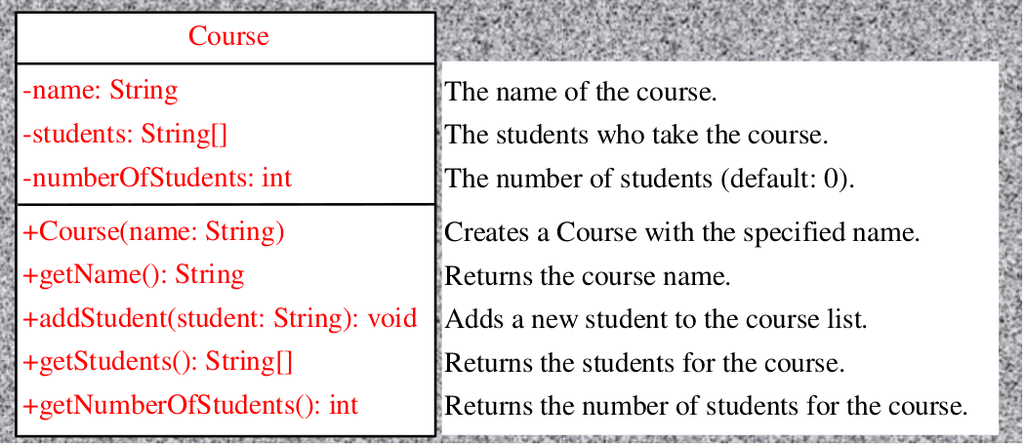

```java
public class Course {
    private String courseName;
    private String[] students = new String[100];
    private int numberOfStudents;

    public Course(String courseName) {
        this.courseName = courseName;
    }

    public void addStudent(String student) {
        students[numberOfStudents] = student;
        numberOfStudents++;
    }

    public String[] getStudents() {
        return students;
    }

    public int getNumberOfStudents() {
        return numberOfStudents;
    }

    public String getCourseName() {
        return courseName;
    }
}
```

```java
public class TestCourse {
    public static void main(String[] args) {
        Course course1 = new Course("Data Structures");
        Course course2 = new Course("Database Systems");

        course1.addStudent("Peter Jones");
        course1.addStudent("Brian Smith");
        course1.addStudent("Anne Kennedy");

        course2.addStudent("Peter Jones");
        course2.addStudent("Steve Smith");

        System.out.println("Number of students in course1: "
            + course1.getNumberOfStudents());
        String[] students = course1.getStudents();
        for (int i = 0; i < course1.getNumberOfStudents(); i++)
            System.out.print(students[i] + ", ");

        System.out.println();
        System.out.print("Number of students in course2: "
            + course2.getNumberOfStudents());
    }
}
```

## طراحی کلاس StackOfIntegers

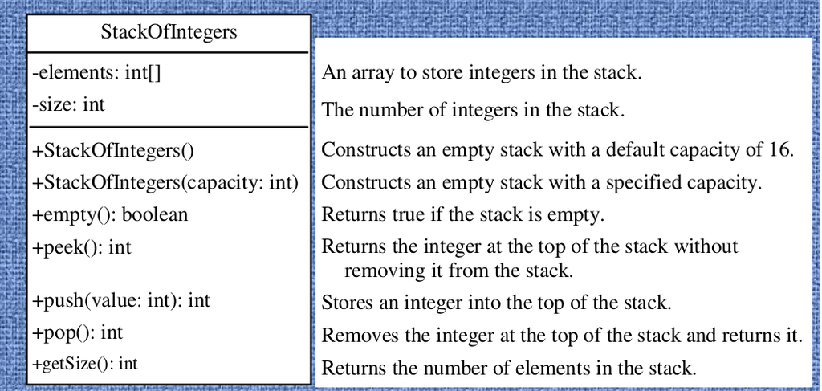

**شماتیک و نحوه کارکرد:**

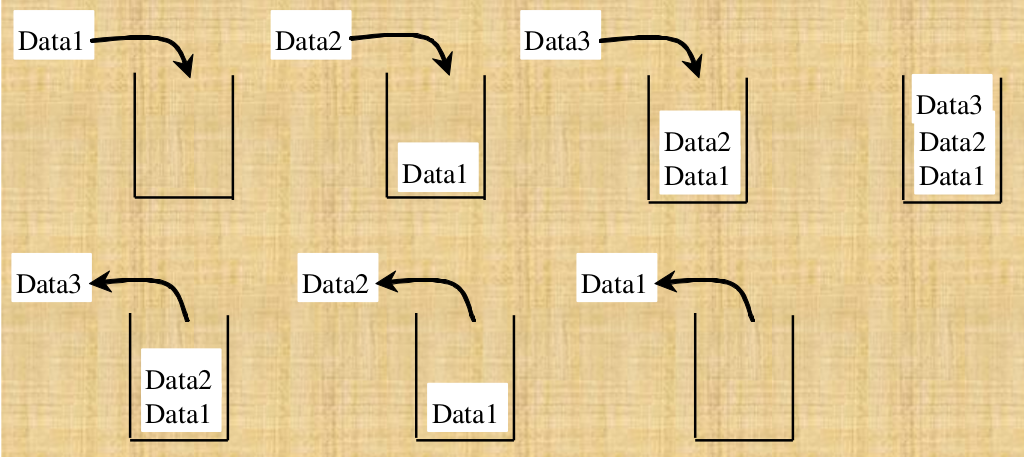

**پیاده‌سازی:**

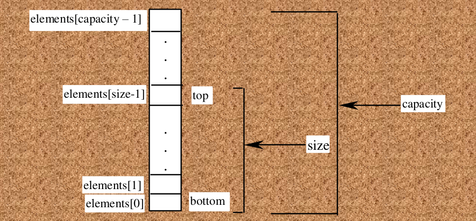

```java
public class StackOfIntegers {
    private int[] elements;
    private int size;
    public static final int DEFAULT_CAPACITY = 16;

    /** Construct a stack with the default capacity 16 */
    public StackOfIntegers() {
        this(DEFAULT_CAPACITY);
    }

    /** Construct a stack with the specified maximum capacity */
    public StackOfIntegers(int capacity) {
        elements = new int[capacity];
    }

    /** Push a new integer into the top of the stack */
    public void push(int value) {
        if (size >= elements.length) {
            int[] temp = new int[elements.length * 2];
            System.arraycopy(elements, 0, temp, 0, elements.length);
            elements = temp;
        }
        elements[size++] = value;
    }

    /** Return and remove the top element from the stack */
    public int pop() {
        return elements[--size];
    }

    /** Return the top element from the stack */
    public int peek() {
        return elements[size - 1];
    }

    /** Test whether the stack is empty */
    public boolean empty() {
        return size == 0;
    }

    /** Return the number of elements in the stack */
    public int getSize() {
        return size;
    }
}
```

### خودمون رو بسنجیم

این بخش برای این طراحی شده که در پایان مطالعه این اسلاید، بتونی خودت رو محک بزنی و ببینی آیا مفاهیم رو به خوبی یاد گرفتی یا نه. سوالات زیر رو مرور کن و سعی کن بدون نگاه کردن به متن درس، به اون ها پاسخ بدی.

- چرا برای تعریف ویژگی‌ها (fields) معمولاً از **private** استفاده می‌کنیم؟
- چطور با استفاده از کپسوله‌سازی (Encapsulation) می‌تونیم امنیت داده‌ها رو حفظ کنیم؟

#### پایان

در صورت هرگونه سوال یا پیشنهاد میتونید با من در ارتباط باشید :)

gmail: foroutanazanin@gmail.com

telegram: @naforoutan